# Introduction to R

Matthew Davis

October 20, 2017

#### Introduction to R

- R is an interpreted language and can be backed by c++ or Java
- Most popular statistical computing language in the world
- Can create graphics, paper, update databases, predict the future
- Open source language with robust online support and package development
- Used by everyone from bio stats researchers to big tech

This document is intended to be a cheat sheet for R basics.

#### Data Types

```r
## vector all integer, numeric, character or factor
## use factor vector for catagorical data
## Vectors are ordered
print(c(1,2,3,4))
```

```
[1] 1 2 3 4
```

```r
print(c('a','b'))
```

```
[1] "a" "b"
```

```r
## data frame columns are vectors (basically a spreadsheet)
print(data.frame(x = c('a', 'b'),y =c(1,2)))
```

```
  x y
1 a 1
2 b 2
```

```r
## matrix all the same data type
print(matrix(0,ncol =2, nrow =2))
```

```
     [,1] [,2]
[1,]    0    0
[2,]    0    0
```

Selecting rows and columns and filter

```r
# Vectors
x = [1:10] # create a vector of integers 1 to 10
x[2] # get the second item of the vector
x[x>4] # get the items in the vector when they are larger than 4
x[order(x, decreasing = TRUE)]  # re order x

# data frames
data(mtcars) # load mtcars
mtcars[,1:10] # select the first 10 rows of mtcars
mtcars[1:2, ] # select the first 2 columns of mtcars
mtcars[,c('mpg', 'cyl')] # select only the mpg and cylndar columns
mtcars[mtcars[, 'cyl'] ==6, ] # select only rows with cars that have 6 cylindars

# list have order, and contain about anything
l = list(x = 1:10, y = 10:24)
l[[1]] # get the values for the first time in the list
l[['x']]# get the values for x time in the list
```

##### Libraries

the library contains packages are essentially files containing functions ‘set of instructions’ and classes ‘containers for storing data’. There is an enormous repository available from CRAN https://cran.r-project.org/

```r
#install.packages('rpart') ## installs a packge from CRAN
library(rpart) ## load a package
detach(package:rpart, unload = TRUE) ## unload a package
```

#### Read and Write csv files

As a note, there lots of parameters for reading in csv to try there are errors reading it in

```r
data(mtcars)
write.csv(mtcars, file = 'mtcars.csv')
newdata = read.csv('mtcars.csv')
head(newdata,2)[1:4]
```

```
              X mpg cyl disp
1     Mazda RX4  21   6  160
2 Mazda RX4 Wag  21   6  160
```

#### Read and Write excel files

R reads only one sheet at a time, if you want to read more, use a for loop. This reads data in as a data frame will have trouble with excel sheets that have graphics or mixed data types

```r
library(xlsx)
data(mtcars)
write.xlsx(mtcars, file = 'mtcars.xlsx')
newdata = read.xlsx('mtcars.xlsx', 1)  ## reads sheet 1
head(newdata,2)[1:4]
```

```
            NA. mpg cyl disp
1     Mazda RX4  21   6  160
2 Mazda RX4 Wag  21   6  160
```

#### Save an R Object and load

```r
load('data.rda')  ## loads the object as rd in env (doesn't use file name for variable name)
save(data, file = 'data.rda')
```

##### Connect to a Database

It’s worth setting up a Windows Data Source Name (DSN) if you are going to do this, so simplify the connection string Also, check in windows data sources to see what odbc drivers are available, if {SQL Server} doesn’t work out of the gate. As a side note, sql server will not connect via odbc from a non-clinician machine

```r
library(RODBC)
### if you set of a DNS, the con<-odbcConnect('dsn')
conString <-'Driver={SQL Server};
              Server=server_name;
              Database=data_base_name;
              Trusted_Connection=Yes;'
con<-odbcDriverConnect(conString)
querryString = ''
data = sqlQuery(con, querryString)
    odbcClose(con)
```

```r
data(mtcars)
summary(mtcars[,c(1,2)]) #summarize data
```

```
      mpg             cyl
 Min.   :10.40   Min.   :4.000
 1st Qu.:15.43   1st Qu.:4.000
 Median :19.20   Median :6.000
 Mean   :20.09   Mean   :6.188
 3rd Qu.:22.80   3rd Qu.:8.000
 Max.   :33.90   Max.   :8.000
```

```r
str(mtcars) # look at underlying stucture of data
```

```
'data.frame':   32 obs. of  11 variables:
 $ mpg : num  21 21 22.8 21.4 18.7 18.1 14.3 24.4 22.8 19.2 ...
 $ cyl : num  6 6 4 6 8 6 8 4 4 6 ...
 $ disp: num  160 160 108 258 360 ...
 $ hp  : num  110 110 93 110 175 105 245 62 95 123 ...
 $ drat: num  3.9 3.9 3.85 3.08 3.15 2.76 3.21 3.69 3.92 3.92 ...
 $ wt  : num  2.62 2.88 2.32 3.21 3.44 ...
 $ qsec: num  16.5 17 18.6 19.4 17 ...
 $ vs  : num  0 0 1 1 0 1 0 1 1 1 ...
 $ am  : num  1 1 1 0 0 0 0 0 0 0 ...
 $ gear: num  4 4 4 3 3 3 3 4 4 4 ...
 $ carb: num  4 4 1 1 2 1 4 2 2 4 ...
```

#### Working with Data Frames

These are basic examples of how to subset, aggregate pivot and un pivot data in a data frame

```r
library(reshape)
aggregate(mtcars,by=list(mtcars[,'cyl']), FUN = mean) #  aggregate
melt(mtcars, id.vars = c('cyl'))  # melt columns
cast(melt(mtcars, id.vars = c('cyl')), value = 'value', fun.aggregate=mean ) # cast ie pivot
```

#### Basic System Utilties

```r
ls()##list all varaibles in environment
list.files() ## list  all files in a working directory
getwd() ## show your working directory
setwd() ## set you working directory
rm() ## remove a variable
rm(list= ls()) ## remove all varabiles in enviroment
class() ## show what type of object
save.image() ## run this to save your enviroment, will open next time you open the project.
```

#### Plot Methods

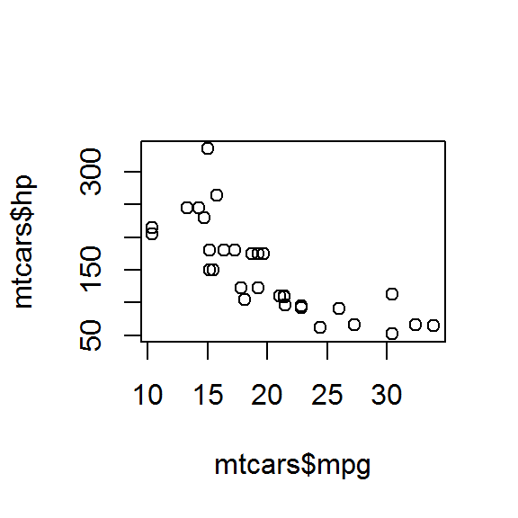

```r
plot(mtcars$mpg, mtcars$hp) # scatter plot
```

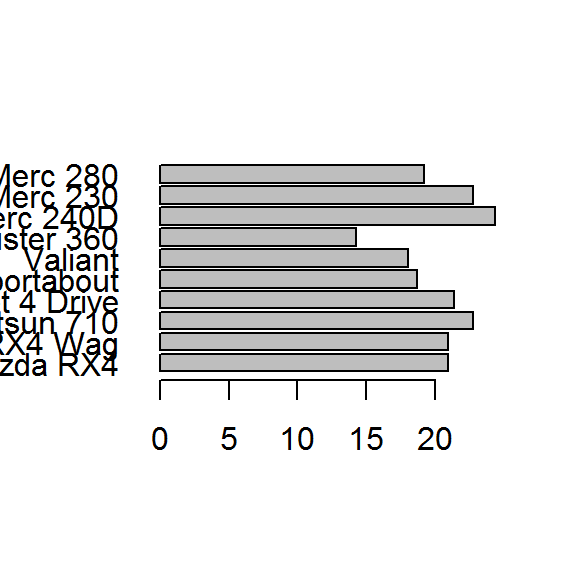

```r
barplot(mtcars$mpg[1:10],names.arg = rownames(mtcars)[1:10], horiz = TRUE, las=1)
```

#### Linear Regression

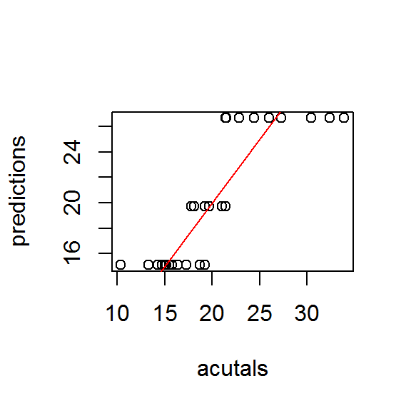

```r
data(mtcars)
f = formula(mpg~hp)
fit = glm(f, mtcars, family='gaussian')
# reference levels
f = formula(mpg~factor(cyl))
fit = glm(f, mtcars, family='gaussian')

plot(x = mtcars$mpg, predict(fit, mtcars), xlab = 'acutals', ylab = 'predictions')
abline(0,1, col = 'red')
```

```r
# basic metrics
MLmetrics::MAE(mtcars$mpg, predict(fit, mtcars))
```

```
[1] 2.359578
```

```r
MLmetrics::R2_Score(mtcars$mpg, predict(fit, mtcars))
```

```
[1] 0.6347378
```

```r
MLmetrics::RMSE(mtcars$mpg, predict(fit, mtcars))
```

```
[1] 3.068299
```

#### Want to Learn More?

Get R to teach you how to program it. I can’t recommend this enough. It a program written in R to teach you how to program R

```r
install.packages('swirl')
library(swirl)
swirl()
```

Don’t google yourself over the edge or start cursing at stackoverflow.

- https://www.statmethods.net/ All Things stats and R and nicely organized
- https://www.r-bloggers.com/ not very organized, but full of information
- https://www.coursera.org/learn/r-programming free course, cheap if you want a certificate